# PPM

## Healthy ingredients of a PPM (Process Performance Model)

My experience in building data models, from a Project's Target setting, prediction and mid-course corrective actions. These actions were followed to obtain a [CMMI Maturity Level 5 Certification](https://cmmiinstitute.com/learning/appraisals/levels)

Summarizing the steps involved in bulding Process Performance Models:

1. Identify Y & study variation
2. Choosing Xs
3. Homogeneity of Xs
4. Removal of Xs
5. Model Validation
6. Model Deployment and Usage
7. Rebuilding the model

Before we begin, it's a good practice to create a document describing the *Data Preparation* Guidelines and Steps involved so the teams are prepared. These may include:

- Service Level Agreements and Key Performance Indicators Documents
- Ticket dumps from IT Service Management/Software Tools
- Software or Service Delivery Team's data, like the employee details and Resolver Groups

**1. Identify Y and study variation:**

Let's say our project Y is Customer Satisfaction in a ticketing process. An I-MR control chart can be used to track the process variability based on the samples taken over a period of time.

```python
import pandas as pd
df = pd.read_csv('/content/drive/MyDrive/Datasets/PPM-case-study-v1.csv')
df.head()
```

|  | Week_Num | Customer_Satisfaction | Resolved_First_Call | Average_Speed_To_Answer | Experience_0-2Yrs_Percent |
| --- | --- | --- | --- | --- | --- |
| 0 | 9 | 0.963415 | 0.814433 | 0.971769 | 0.666667 |
| 1 | 10 | 0.986486 | 0.848485 | 0.966065 | 0.710000 |
| 2 | 11 | 0.943182 | 0.878049 | 0.985775 | 0.500000 |
| 3 | 12 | 0.964706 | 0.835294 | 0.974433 | 0.600000 |
| 4 | 13 | 0.967391 | 0.817073 | 0.950240 | 0.650000 |

```python
df.describe()
```

|  | Week_Num | Customer_Satisfaction | Resolved_First_Call | Average_Speed_To_Answer | Experience_0-2Yrs_Percent |
| --- | --- | --- | --- | --- | --- |
| count | 27.000000 | 27.000000 | 27.000000 | 27.000000 | 27.000000 |
| mean | 22.000000 | 0.943501 | 0.762812 | 0.934111 | 0.555626 |
| std | 7.937254 | 0.027951 | 0.062703 | 0.026929 | 0.142547 |
| min | 9.000000 | 0.886667 | 0.602041 | 0.877095 | 0.250000 |
| 25% | 15.500000 | 0.920998 | 0.718288 | 0.912943 | 0.439286 |
| 50% | 22.000000 | 0.951807 | 0.771739 | 0.936737 | 0.600000 |
| 75% | 28.500000 | 0.963415 | 0.807143 | 0.952319 | 0.673333 |
| max | 35.000000 | 0.988372 | 0.878049 | 0.985775 | 0.750000 |

```python
df['Diff'] = abs(df['Customer_Satisfaction'].diff()) #returns difference of the value and the preceding value
```

```python
df.head()
```

|  | Week_Num | Customer_Satisfaction | Resolved_First_Call | Average_Speed_To_Answer | Experience_0-2Yrs_Percent | Diff |
| --- | --- | --- | --- | --- | --- | --- |
| 0 | 9 | 0.963415 | 0.814433 | 0.971769 | 0.666667 | NaN |
| 1 | 10 | 0.986486 | 0.848485 | 0.966065 | 0.710000 | 0.023072 |
| 2 | 11 | 0.943182 | 0.878049 | 0.985775 | 0.500000 | 0.043305 |
| 3 | 12 | 0.964706 | 0.835294 | 0.974433 | 0.600000 | 0.021524 |
| 4 | 13 | 0.967391 | 0.817073 | 0.950240 | 0.650000 | 0.002685 |

```python
df.shape
```

```
(27, 6)
```

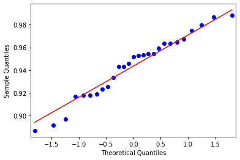

```python
from statsmodels.graphics.gofplots import qqplot
from matplotlib import pyplot as plt
%matplotlib inline

data = df['Customer_Satisfaction']
qqplot(data, line='s')
plt.show()
```

```python
from scipy import stats
stats.anderson(data,dist='norm')
```

```
AndersonResult(statistic=0.39960035339271727, critical_values=array([0.517, 0.589, 0.707, 0.824, 0.98 ]), significance_level=array([15. , 10. ,  5. ,  2.5,  1. ]))
```

The Statistic returned, 0.399 is less than the critical value 0.707 at significance level 5%. Hence we fail to reject the null hypothesis that Data is Normal

This is confirmed by the normality test below. Since the p value is > .05.

```python
stats.normaltest(data)
```

```
NormaltestResult(statistic=1.2484339335029948, pvalue=0.5356807201523828)
```

The [Table of Constants](https://web.mit.edu/2.810/www/files/readings/ControlChartConstantsAndFormulae.pdf) for control chart

gives you the below values for constants:

```python
# Constant for n = 2
E2 = 2.66
D3 = 0
D4 = 3.267
```

```python
mr = df['Diff']
mr_bar = mr.mean()
mr_bar
```

```
0.022679839896153835
```

```python
i = df['Customer_Satisfaction']
i_bar = i.mean()
```

```python
#I chart control limits
uclx = i_bar + E2 * mr_bar
lclx = i_bar - E2 * mr_bar
```

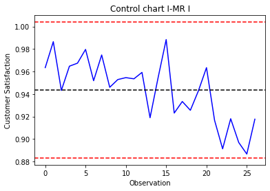

```python
import matplotlib.pyplot as plt
%matplotlib inline
fig, ax = plt.subplots()
ax.plot(i,color = 'blue')
ax.axhline(i_bar,color = 'black',linestyle = '--')
ax.axhline(lclx, color = 'red',linestyle = '--')
ax.axhline(uclx, color = 'red',linestyle = '--')
ax.set_xlabel('Observation')
ax.set_ylabel('Customer Satisfaction')
ax.set_title('Control chart I-MR I')
plt.show()
```

```python
# MR chart control Limits
uclr = D4 * mr_bar
lclr = D3 * mr_bar
```

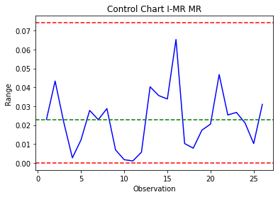

```python
import matplotlib.pyplot as plt
%matplotlib inline
fig, ax = plt.subplots()
ax.plot(mr,color = 'blue')
ax.axhline(mr_bar,color = 'green',linestyle = '--')
ax.axhline(lclr, color = 'red',linestyle = '--')
ax.axhline(uclr, color = 'red',linestyle = '--')
ax.set_xlabel('Observation')
ax.set_ylabel('Range')
ax.set_title('Control Chart I-MR MR')
plt.show()
```

List down Xs which might influence Y significantly Select Xs based on people, process and product factor Xs should be tweakable and controllable in nature

[output not shown]

Homogeneity of Xs, points to look out for:

- The spread or variance has to be consistent across the range of values
- It can be visualized with a box plot and
- The dots are spread out fairly evenly across the line

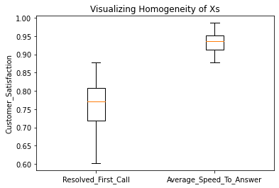

```python
fig, ax = plt.subplots()
ax.boxplot([df['Resolved_First_Call'],df['Average_Speed_To_Answer']])
ax.set_xticklabels(['Resolved_First_Call','Average_Speed_To_Answer'])
ax.set_ylabel('Customer_Satisfaction')
ax.set_title('Visualizing Homogeneity of Xs')
plt.show()
```

Model Building and verification:

```python
#from sklearn import linear_model
#regr = linear_model.LinearRegression()
#regr.fit(X,Y)
```

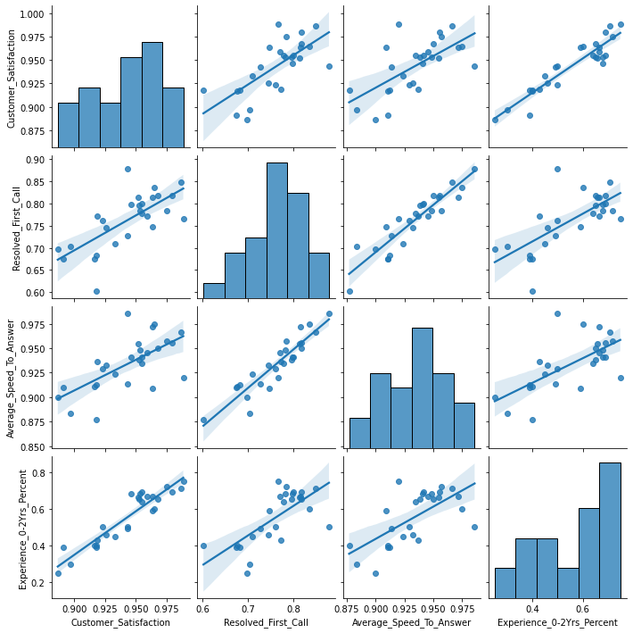

```python
import seaborn
df_X_Y = df.drop(columns = ['Week_Num','Diff'], axis=1)
seaborn.pairplot(df_X_Y,kind="reg")
```

Remove any X's if there's no apparent linear relationship

We see the Xs are highly correlated with each other, could lead to multicollinearity. Let's drop Average Speed to Answer (There are other methods to handle multicollinearity, for the sake of simplicity and illustration let's drop one highly correlated X)

```python
x = df[['Resolved_First_Call','Experience_0-2Yrs_Percent']]
Y = df['Customer_Satisfaction']
```

```python
import statsmodels.api as sm
X = sm.add_constant(x) #Our model needs an intercept so we add a column of 1s:
print(X)
```

```
    const  Resolved_First_Call  Experience_0-2Yrs_Percent
0     1.0             0.814433                   0.666667
1     1.0             0.848485                   0.710000
2     1.0             0.878049                   0.500000
3     1.0             0.835294                   0.600000
4     1.0             0.817073                   0.650000
5     1.0             0.818182                   0.690000
6     1.0             0.814286                   0.660000
7     1.0             0.783784                   0.720000
8     1.0             0.797297                   0.680000
9     1.0             0.795181                   0.650000
10    1.0             0.800000                   0.690000
11    1.0             0.783019                   0.680000
12    1.0             0.770492                   0.666667
13    1.0             0.771739                   0.428571
14    1.0             0.777778                   0.640000
15    1.0             0.765957                   0.750000
16    1.0             0.760870                   0.500000
17    1.0             0.709302                   0.450000
18    1.0             0.744898                   0.460000
19    1.0             0.727273                   0.490000
20    1.0             0.746835                   0.590000
21    1.0             0.675676                   0.400000
22    1.0             0.674419                   0.390000
23    1.0             0.682353                   0.390000
24    1.0             0.703297                   0.300000
25    1.0             0.697917                   0.250000
26    1.0             0.602041                   0.400000
```

```python
ols_model = sm.OLS(Y,X)
print(ols_model)
```

```
<statsmodels.regression.linear_model.OLS object at 0x7f6d0c95a6d0>
```

```python
ols_results = ols_model.fit()
print(ols_results)
```

```
<statsmodels.regression.linear_model.RegressionResultsWrapper object at 0x7f6d0c8eb210>
```

```python
print(ols_results.summary())
```

```
                              OLS Regression Results
=================================================================================
Dep. Variable:     Customer_Satisfaction   R-squared:                       0.869
Model:                               OLS   Adj. R-squared:                  0.858
Method:                    Least Squares   F-statistic:                     79.42
Date:                   Sun, 27 Feb 2022   Prob (F-statistic):           2.62e-11
Time:                           02:36:42   Log-Likelihood:                 86.198
No. Observations:                     27   AIC:                            -166.4
Df Residuals:                         24   BIC:                            -162.5
Df Model:                              2
Covariance Type:               nonrobust
=============================================================================================
                                coef    std err          t      P>|t|      [0.025      0.975]
---------------------------------------------------------------------------------------------
const                         0.8186      0.029     28.478      0.000       0.759       0.878
Resolved_First_Call           0.0399      0.047      0.856      0.400      -0.056       0.136
Experience_0-2Yrs_Percent     0.1699      0.021      8.279      0.000       0.128       0.212
==============================================================================
Omnibus:                        1.694   Durbin-Watson:                   1.814
Prob(Omnibus):                  0.429   Jarque-Bera (JB):                1.429
Skew:                          -0.413   Prob(JB):                        0.489
Kurtosis:                       2.233   Cond. No.                         38.1
==============================================================================

Warnings:
[1] Standard Errors assume that the covariance matrix of the errors is correctly specified.
```

**It would be good if we can get a model with Condition Number <20 further, to avoid multicollinearity increasing the variance of the regression coefficients**

Let's take a look at the Test set:

```python
df_test = pd.read_csv('/content/drive/MyDrive/Datasets/PPM-case-study-v1-test.csv')
```

```python
df_test
```

|  | Week_Num | Customer_Satisfaction | Resolved_First_Call | Average_Speed_To_Answer | Experience_0-2Yrs_Percent |
| --- | --- | --- | --- | --- | --- |
| 0 | 36 | 0.92 | 0.68 | 0.92 | 0.45 |
| 1 | 37 | 0.88 | 0.66 | 0.90 | 0.38 |
| 2 | 38 | 0.92 | 0.69 | 0.92 | 0.40 |
| 3 | 39 | 0.90 | 0.71 | 0.89 | 0.31 |
| 4 | 40 | 0.87 | 0.68 | 0.88 | 0.25 |
| 5 | 41 | 0.92 | 0.61 | 0.88 | 0.42 |

Let's try and predict the value of Y (Customer Satisfaction) for the above test data set

```python
x_test_set = df_test[['Resolved_First_Call','Experience_0-2Yrs_Percent']]
x_test = sm.add_constant(x_test_set)
```

```python
ypred = ols_results.predict(x_test)
print(ypred)
```

```
0    0.922247
1    0.909555
2    0.914151
3    0.899659
4    0.888267
5    0.914353
dtype: float64
```

```python
df_predicted_column = pd.DataFrame({'Predicted_Customer_Satisfaction': ypred})
```

```python
df_predicted_column
```

|  | Predicted_Customer_Satisfaction |
| --- | --- |
| 0 | 0.922247 |
| 1 | 0.909555 |
| 2 | 0.914151 |
| 3 | 0.899659 |
| 4 | 0.888267 |
| 5 | 0.914353 |

We can now compare the predicted vs actual from the test data set. If the Mean Absolute Error (MAE) is greater than an pre-determined acceptable level (like +/-3%) as an example, then the model needs to be re-evaluated.

If the MAE is acceptable we may proceed with PPM usage and Mid Course Corrective actions as required

Using the Formula returned by the Regression Equation, Different **Scenarios** can be created. Each scenario whould have a projected value of Y (Customer Satisfaction) with it's corresponding value of X's (Resolved on First Call and Percentage of People with 0-2 years of Experince in the Project involved in working those tickets)

### Process Performance Model Usage:

- Target for Y, (Customer Satisfaction) is taken as, let's say 96%. * The equation will tell you, the performance of X's that need to be achieved, in-order to meet the target of Y. It is important for the team to achieve that level of performance for the X's.
- X's are tracked daily using control charts. In this case P-Chart.

### Using PPM for Mid Course Corrective Action, What-If Analysis and re-planning

- Target for controllable parameters are set at the beginning of the month
- By mid-month, if the performance of the controllable X's are changed significantly, PPMs are used for Mid-Course Corrective action and Re-planning inorder to achieve the target Y

### If we find over-time, the MAE is not acceptable, we need to rebuild the model